title: | Bayesian Small Area Estimation of Under-Five Malaria Prevalence in West Africa subtitle: | A Space-Time BYM2 Fay-Herriot Model Across Ghana, Burkina Faso and Côte d’Ivoire # Scaffold the template once before knitting: # rmarkdown::draft(“final_report_writeup.Rmd”, template = “arxiv”, package = “rticles”) authors: - name: Godwill Zulu affiliation: | School of Mathematics, Statistics and Applied Mathematics, University of Galway, Galway, Ireland email: g.zulu1@universityofgalway.ie - name: Stewart Hagen affiliation: | School of Mathematics, Statistics and Applied Mathematics, University of Galway, Galway, Ireland # Supervisor: Dr Nicola Fitz-Simon abstract: | Reliable district-level estimates of malaria prevalence in children under five are essential for targeting intervention resources, monitoring progress against the WHO Global Technical Strategy and evaluating equity, but Demographic and Health Surveys (DHS) are designed to be representative at the regional level rather than at finer administrative scales. We develop a Bayesian hierarchical area-level Fay-Herriot framework with a BYM2 spatial prior to produce smoothed district-level prevalence estimates for under-five malaria across Burkina Faso, Côte d’Ivoire and Ghana, using two DHS rounds per country spanning the 2010 to 2022 period. The modelling sequence builds up from a single-country cross-sectional baseline to country-level space-time models, then to a three-country single-time model (Model 3) and a three-country two-time model (Model 4) that share a single 724-district adjacency graph including cross-border edges. A formal sensitivity analysis assesses the cross-border adjacency assumption, the time-invariance of covariate slopes, and the assumption of shared versus country-specific BYM2 hyperparameters using leave-one-out cross-validation. The cross-sectional baseline empirically prefers the BYM2 prior over both pure ICAR and IID alternatives. The country-level and cross-border models recover three distinct trajectories: substantial declines in Burkina Faso and Ghana, and a marked increase in Côte d’Ivoire between 2012 and 2021. None of three structural relaxations of Model 4 produces a detectable improvement in expected log predictive density, so the simpler shared-adjacency calendar-year specification is parsimoniously adequate and is retained as the preferred specification. keywords: - small area estimation - Bayesian hierarchical model - BYM2 spatial prior - Fay-Herriot - malaria prevalence - West Africa - Demographic and Health Surveys bibliography: references.bib biblio-style: unsrtnat output: rticles::arxiv_article: citation_package: natbib header-includes: -

# Introduction

## Background

Malaria remains one of the leading causes of childhood morbidity and mortality in sub-Saharan Africa. The World Health Organization estimated 263 million cases and 597,000 deaths globally in 2023, of which approximately 94 per cent occurred in the African Region [@who2023]. The burden is geographically heterogeneous within countries: districts only short distances apart can differ in prevalence by tens of percentage points, reflecting local variation in vector ecology, climatic suitability, intervention coverage and socioeconomic conditions [@bhatt2015; @weiss2020]. Sub-national estimates of prevalence at the district scale are therefore essential for targeting intervention resources, monitoring progress against the WHO Global Technical Strategy for Malaria 2016 to 2030 [@who2023], and evaluating the equity of malaria control programmes.

Demographic and Health Surveys (DHS) are one of the most widely used sources of nationally representative malaria prevalence data in sub-Saharan Africa, with parasite rapid diagnostic tests (RDTs) conducted on children aged 6 to 59 months in standardised survey designs [@croft2018]. The DHS sampling design uses stratification by administrative region and stratified two-stage cluster sampling, with districts (admin-2 or admin-3 units) generally not used as explicit strata. Direct survey-based estimates at the district level are therefore based on a small number of clusters per district and have sampling variances too large for reliable interpretation [@rao2015; @wakefield2020]. In our data, many districts are sampled with too few clusters to permit a stable design-based estimate, and a substantial number of districts are not sampled at all in a given round.

## Literature review

Small area estimation (SAE) emerged as a distinct methodological tradition in survey statistics from the 1970s onwards as governments sought reliable sub-national statistics from surveys whose representativeness had been designed only at the national or regional level [@rao2015]. The foundational area-level contribution is the Fay-Herriot model [@fay1979], which models a design-based direct estimate from each area as a noisy observation of an underlying true value, with sampling variance treated as known and a linking model relating the true value to area covariates and area-level random effects. The unit-level counterpart of [@battese1988] models the individual response directly; area-level approaches are typically preferred when only published or weighted summaries are available, or when the auxiliary information is itself only available at area scale. [@rao2015] provides a comprehensive synthesis of the field, including empirical-Bayes and hierarchical-Bayes treatments and the variance components literature.

Spatial extensions of the Fay-Herriot framework recognise that neighbouring areas are typically more similar to each other than distant areas. The intrinsic conditional autoregressive (ICAR) prior of [@besag1991] formalises this through a Gaussian Markov random field on an adjacency graph. The original BYM convolution model of [@besag1991] combined the structured ICAR component with an independent Gaussian component, but suffered from non-identifiability between the two variance parameters. The BYM2 reparameterisation of [@riebler2016] fixes this by introducing a mixing parameter $\phi \in (0,1)$ and a common marginal standard deviation, yielding a single interpretable spatial scale and stable identifiability. The disconnected-graph treatment of [@freni2018] extends the BYM2 to graphs with multiple components by scaling each component separately. [@morris2019] documents an efficient Stan implementation that has become a de facto reference for applied work.

Disease mapping for malaria has been dominated by two methodological streams. The first is the model-based geostatistics tradition, exemplified by the Malaria Atlas Project [@bhatt2015; @weiss2020], which fits Gaussian process models to cluster-level positivity data and produces continuous prevalence surfaces at pixel resolution (typically 5 km). The Malaria Atlas Project surfaces have been highly influential for global burden estimation and trend monitoring, and underpin the WHO Global Technical Strategy targets [@who2023]. They are however not designed to deliver district-level estimates with quantified district-level uncertainty for programme planning: the aggregation step from pixels to administrative units involves non-trivial uncertainty propagation that the published outputs do not carry explicitly. The second stream is area-level SAE on administrative geographies, in the tradition of [@mercer2015], [@diggle2007] and [@wakefield2020], which models a transformed direct estimate per area and is the framework most directly aligned with the decision unit of national malaria control programmes. This work sits in the second stream and complements the Malaria Atlas Project rather than competing with it: the district-level estimates produced here can be compared to the corresponding aggregated MAP surfaces as a concordance check while preserving the administrative-unit uncertainty required for resource allocation decisions.

Three more recent methodological developments shape the present work. [@wakefield2020] formalises area-level SAE for prevalence outcomes from DHS-like surveys, distinguishing carefully between design-based direct estimates, model-based smoothed estimates, and the calendar-time parameterisation of temporal effects in surveys whose fieldwork windows are not exactly synchronised across countries. The Type I unstructured space-time interaction of [@knorrheld2000] gives a parsimonious treatment of round-by-district random variation that remains identifiable with only two time points per area. The hierarchical-prior treatment of country-specific covariate slopes follows [@gelman2006]. Multi-country pooling of administrative-unit SAE on a single graph that includes cross-border edges has, to our knowledge, not been systematically explored for malaria in West Africa; the closest precedents are continental-scale geostatistical work in the MAP tradition and country-by-country SAE in the [@mercer2015] tradition.

## Cross-border modelling and the shared adjacency graph

A defining choice in this work is whether the three countries should be analysed jointly on a single combined adjacency graph that includes cross-border edges, or as three separate within-country analyses. The substantive case for the shared adjacency graph is that malaria transmission ecology does not respect national borders. *Plasmodium falciparum* dominates transmission in West Africa and shares *Anopheles gambiae* and *Anopheles funestus* vector species across the three study countries [@who2023]. The West African monsoon drives a regional July to October transmission peak and a north to south climatic gradient that the political borders cut transversely [@bhatt2015]. Mobile human populations disperse the parasite across borders, and the structural determinants of risk (climate, elevation, urbanisation, accessibility) are themselves spatially smooth across the region [@weiss2020].

At the same time, joining three countries on a single graph raises a methodological question about the temporal alignment of the surveys. The first survey rounds span four calendar years (Burkina Faso 2010, Côte d’Ivoire 2012, Ghana 2014), and a spatial smoother that treats cross-border edges in the first round as if they connected contemporaneous surfaces would conflate spatial with temporal variation [@saldarriaga2020]. The cross-border modelling sequence addresses this concern through a layered strategy. A three-country single-time model (Model 3) uses only the temporally aligned second survey round, removing the temporal misalignment by construction. A three-country spatiotemopralmodel model (Model 4) extends to both rounds with country-specific linear slopes on calendar year, following [@wakefield2020]. Three further specifications test the structural assumptions of Model 4: time-varying covariate slopes (Model 4a), country-specific BYM2 hyperparameters (Model 4b), and an edge-deletion sensitivity that removes the cross-border edges and refits Model 4 on the disconnected graph. The relative merits of each specification are assessed by leave-one-out cross-validation [@vehtari2017].

# Methods

## Data

### DHS data and confidentiality

The malaria outcome and the survey-design metadata are drawn from the DHS programme [@croft2018]. Access to the household member recode files and the cluster GPS shapefiles requires a project application to the DHS Program, which the present project obtained. The DHS data are confidential: cluster coordinates are randomly displaced (up to 2 km in urban areas, 5 km in rural areas, with 1 per cent of rural clusters displaced up to 10 km) to protect respondent confidentiality, and the data licence does not permit redistribution of the recode files or the displaced GPS coordinates beyond the approved project team. All results in this report were produced from the licensed copies of the data held within the project; no individual-level data are reproduced in this document. The GPS displacement is small relative to the admin-2/admin-3 polygons used here, so spatial assignment of clusters to districts uses the nearest-feature rule rather than strict point-in-polygon to avoid spurious mis-assignments near district borders, following standard DHS spatial-analysis practice.

### Survey instruments and outcome

The outcome is the result of an RDT for *Plasmodium falciparum* infection administered to children aged 6 to 59 months. Six DHS surveys are used in this study (Table $\ref{tab:surveys}$). The two rounds per country are separated by 8 to 11 calendar years, and the within-round fieldwork windows span the late wet-season and early dry-season months in each country.

DHS surveys used in this study, by country and round.

[output not shown]

### Administrative boundaries

District boundaries were obtained from the Database of Global Administrative Areas (GADM, version 4.1) and harmonised to the finest administrative geography at which malaria control programmes are implemented in each country. For Ghana the district (admin-2) geography contains 260 polygons (260 districts as of the 2021 redrawing following the 2018 demarcation review). For Burkina Faso the commune (admin-3) geography contains 351 polygons; the older 45-province admin-2 layer is coarser than the operational level used by the national malaria control programme and is not adopted here. For Côte d’Ivoire the department (admin-3) geography contains 113 polygons. The three administrative geographies are therefore harmonised at the admin-2 level for Ghana and the admin-3 level for Burkina Faso and Côte d’Ivoire, giving the finest comparable units across the three countries and a combined panel of $N = 724$ districts. A small number of districts changed boundaries between rounds; these were handled by majority-area cross-walks documented in the methodological workbook.

### Direct estimation and the motivation for small area estimation

For each district $i$ in survey round $t$, the design-based direct estimate of malaria prevalence is the Hájek estimator [@hajek1971],
$$\begin{equation}
\hat{p}_{it} \;=\; \frac{\sum_{k \in S_{it}} w_k \, m_k}{\sum_{k \in
S_{it}} w_k},
\label{eq:hajek}
\end{equation}$$
where $S_{it}$ is the set of sampled children in district $i$ at round $t$, $w_k$ is the survey weight of child $k$, and $m_k \in \{0, 1\}$ is the RDT result. The Hájek estimator is preferred over the Horvitz-Thompson estimator because the denominator is also estimated from the survey, which reduces variability when sample sizes within domains are small [@cochran1977; @lumley2010]. The design-based sampling variance $\widehat{\mathrm{Var}}(\hat{p}_{it})$ is computed by Taylor-series linearisation [@binder1983] using a `svydesign` specification with primary sampling unit and stratum information from the DHS recode files. The logit transform $y_{it} = \mathrm{logit}(\hat{p}_{it})$ gives a quantity on the unbounded real line; the associated sampling variance on the logit scale follows from the delta method,
$$\begin{equation}
\psi_{it}^2 \;=\;
\frac{\widehat{\mathrm{Var}}(\hat{p}_{it})}{\bigl[\hat{p}_{it}(1 -
\hat{p}_{it})\bigr]^2}.
\label{eq:psi}
\end{equation}$$
Direct estimates of exactly zero or one are handled by a small continuity adjustment; districts with zero observed clusters in a round are flagged as unobserved and enter the model only through the spatial and covariate structure.

The Hájek estimator and its design-based variance are well behaved when the sample size per district is large and the design effect is moderate. At the district scale of the DHS surveys used here neither condition holds reliably, and three properties of the resulting direct estimates motivate the model-based approach that follows: many districts are not sampled at all, those that are sampled are typically supported by very few clusters, and regional aggregation as a workaround masks substantial district-level heterogeneity.

The DHS surveys used here apply a stratified two-stage cluster design with explicit stratification by administrative region (admin-1) crossed with urban/rural residence [@croft2018]. Within each stratum, enumeration areas (the primary sampling units, equivalent to one DHS *cluster*) are selected with probability proportional to size from the most recent national census frame. Within each sampled cluster a fixed target number of households is enlisted, all eligible women aged 15–49 are interviewed, and the malaria submodule tests all consenting children aged 6–59 months for *Plasmodium falciparum* infection by rapid diagnostic test. The design is powered to deliver reliable region-level prevalence estimates: cluster counts per stratum are chosen so that the design-effect-adjusted standard error of the regional Hájek estimator meets a pre-specified precision target for the national report.

The district is not an explicit stratum of any of the DHS designs used here. From the district’s perspective the survey is an *unplanned domain* in the language of [@rao2015]: the cluster count allocated to a district is whatever falls out of the region-level allocation, and there is no design guarantee that it will be large enough to support a direct estimator at that scale. The direct estimator in equation $\ref{eq:hajek}$ is still defined whenever at least one cluster falls in a district, and its variance in equation $\ref{eq:psi}$ is still computable, but neither quantity carries any design-based precision guarantee at the district level. Two consequences follow.

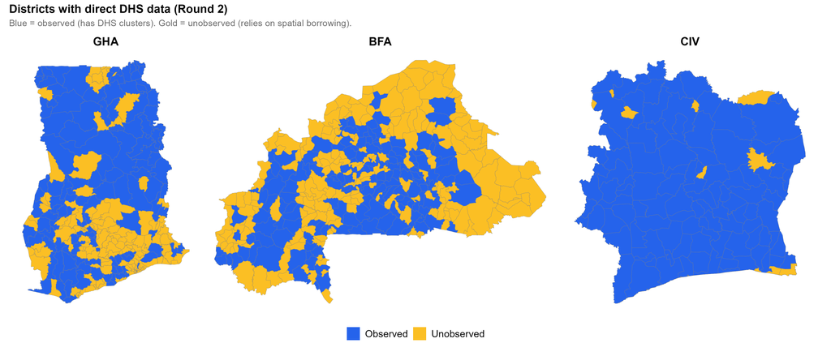

[output not shown]

For the districts that do contain at least one cluster, the cluster count is heavily concentrated in the single digits. A DHS cluster contains around 25–30 sampled households, of which a smaller subset have eligible children tested for malaria, so the effective number of under-five RDT results per district often sits in the low tens; once the design effect from within-cluster homogeneity in malaria risk is accounted for, the *effective sample size* for variance purposes is smaller still. Many observed districts contain fewer than ten clusters per round, and a substantial minority contain fewer than five. With a binary outcome and an effective sample size in the single or low double digits, the binomial sampling distribution is not well approximated by its asymptotic Normal: variance estimates are themselves uncertain, confidence intervals undercover, and continuity issues arise at $\hat{p}$ values of zero and one [@korn1998].

The district-level design-based variance in equation $\ref{eq:psi}$ can be written approximately as
$$\begin{equation}
\widehat{\mathrm{Var}}(\hat{p}_{it}) \;\approx\; \mathrm{deff}_{it}
\cdot \frac{\hat{p}_{it}(1 - \hat{p}_{it})}{n_{it}^{\mathrm{eff}}},
\label{eq:district-var}
\end{equation}$$
for an effective sample size $n_{it}^{\mathrm{eff}}$ and a design effect $\mathrm{deff}_{it}$ from the cluster sampling [@cochran1977; @lumley2010]. With $n_{it}^{\mathrm{eff}}$ in the tens and $\mathrm{deff}_{it}$ between roughly 1.5 and 3, the per-district standard error is substantial; for low-prevalence districts in particular the *coefficient of variation* $\mathrm{CV}_{it} = \mathrm{SE}(\hat{p}_{it}) / \hat{p}_{it}$ explodes because the numerator shrinks faster than the denominator.

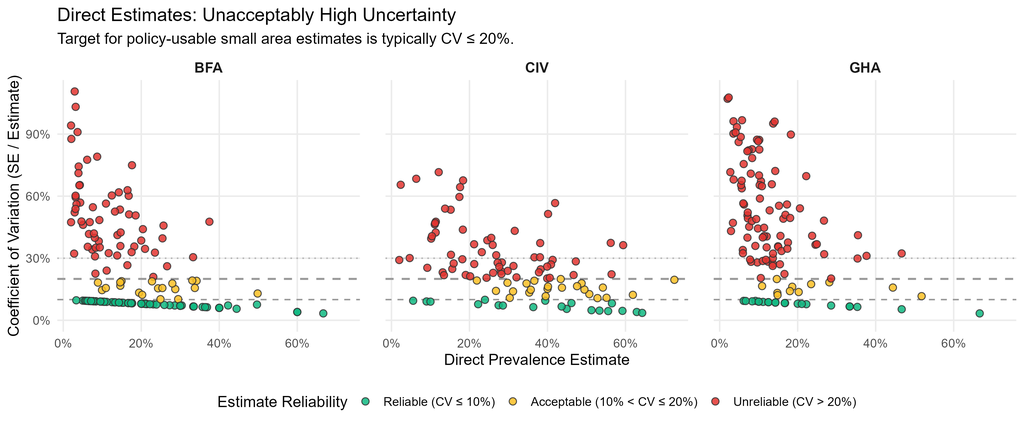

Coefficient of variation (SE divided by direct estimate) versus the direct estimate by country, pooled across both survey rounds. Colour denotes the operational reliability band used in the SAE literature: reliable (CV at or below 10 per cent, green), acceptable (CV between 10 and 20 per cent, amber), unreliable (CV above 20 per cent, red). In every country a clear majority of sampled districts cross into the unreliable band, with the worst CVs concentrated at low prevalence.

A natural reaction to the variance problem is to abandon the district scale and report at the admin-1 level instead, accepting the loss of resolution to gain stability. The cost of that reaction is shown in Figure $\ref{fig:aggregation}$. The same survey wave that produces a regional prevalence of around 18 per cent a value that on its own would suggest a uniform, low-to-moderate burden across the region masks a single district within that region whose direct prevalence is above 55 per cent. The region-level number is correct as a weighted average but is not the quantity a malaria programme manager needs in order to decide where to deploy the next round of net distribution, indoor residual spraying, or seasonal chemoprevention. This is the canonical aggregation/ecological-bias problem in spatial epidemiology [@bhatt2015; @weiss2020]: the operational unit of intervention is the district, not the region, and a regional estimator either misses the district-level hotspot entirely or attributes it uniformly across districts that in reality vary by tens of percentage points.

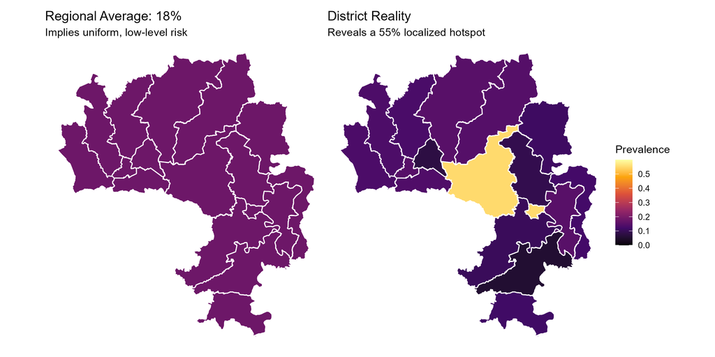

Regional aggregation masks district-level heterogeneity. Left panel shows the admin-1 regional average prevalence (18 per cent) for the same survey wave shown in the right panel; right panel shows the underlying district-level direct estimates, revealing a localised hotspot at 55 per cent. The regional summary is correct as a weighted average but is not the quantity required for programme targeting.

The three problems, the data desert in unsampled districts, the variance explosion in lightly sampled districts, and the heterogeneity masked by regional aggregation, are simultaneously the motivation for small area estimation and the dimensions along which it delivers. The Fay-Herriot framework set out below addresses the data desert by treating an unobserved district as a missing direct observation whose latent value $\theta_{it}$ is still predicted through the covariates and the spatial neighbours under the linking model. It addresses the variance explosion by partial pooling: the model-based posterior at any sampled district is a precision-weighted compromise between the direct estimate and the model-implied value, with weights determined by the relative magnitude of the sampling variance $\psi_{it}^2$ from equation $\ref{eq:psi}$ and the residual model variance [@rao2015; @wakefield2020]. And it preserves the district as the unit of inference, producing the district-scale estimate that the policy unit requires while drawing strength from the regional design that the survey was actually sized for. The cross-sectional baseline (Section $\ref{sec:results}$) demonstrates these three improvements directly, by comparing the model-based estimates against the direct estimates on the Ghana 2022 cross-section.

### Covariates

Seven district-level covariates are included in the cross-border models. The covariate set is selected to capture the dominant ecological and structural determinants of malaria transmission identified in the regional and global literature [@bhatt2015; @weiss2020]. The substantive justification for each covariate is in Table $\ref{tab:covariates}$. Covariate values for each district-round were extracted using the actual DHS fieldwork months of that survey, so that seasonal variation in rainfall and temperature is captured at the data level rather than through an explicit seasonality term in the model. Each covariate was standardised to unit variance and zero mean prior to model fitting.

The covariates were assembled from three distinct data sources, each operating at a different native spatial resolution. The first source is remote-sensed raster surfaces: elevation from the SRTM 1 km digital elevation model, rainfall from CHIRPS daily precipitation [@funk2015; @weiss2020], land surface temperature from the MODIS LST product, and nighttime lights from the VIIRS annual composite [@elvidge2014; @elvidge2021]. Each raster was clipped to district polygons and aggregated to the population-weighted district mean using WorldPop population counts as the weighting surface. The travel time to the nearest city is taken from the global friction surface of [@weiss2020]. Population density is computed from the WorldPop population counts divided by district land area, log-transformed to handle the heavy right tail.

The second source is country-specific census tabulations for the poverty covariate. Ghana publishes a district-level multidimensional poverty index through the Ghana Statistical Service StatsBank API at the admin-2 level, which was queried directly for each Ghanaian district. Burkina Faso publishes its poverty data at the regional (admin-1) level through the *Recensement Général de la Population et de l’Habitation* (RGPH 2019), and Côte d’Ivoire publishes its multidimensional poverty index at the regional (admin-1) level through the *Enquête sur le Niveau de Vie des Ménages* (ENV 2015). For these two countries, the regional poverty value was assigned uniformly to every district within the region.

The third source is the official admin-2/admin-3 shapefile from each country for boundary information.

Covariates used in the cross-border models, the substantive mechanism for the malaria-prevalence relationship, the data source and the primary reference.

| Covariate | Mechanism | Source | Reference |
| --- | --- | --- | --- |
| Elevation | Altitude lowers ambient temperature and slows parasite development inside Anopheles vectors. | SRTM 1km DEM | Bhatt et al. (2015) |
| Rainfall | Rainfall sustains vector breeding sites; wet-season totals are a standard environmental driver. | CHIRPS daily precip. | Funk et al. (2015) |
| Temperature | Temperature governs vector survival and the extrinsic incubation period; optimum near 25 C. | MODIS LST | Bhatt et al. (2015) |
| Nighttime lights | Urbanisation reduces larval habitat and improves housing and healthcare access. | VIIRS composite | Elvidge et al. (2021) |
| Travel time | Accessibility from major centres reflects the practical reach of interventions and treatment. | Friction surface | Weiss et al. (2020) |
| Pop. density | Density modifies effective transmission intensity and human-vector contact rates. | WorldPop + shapefile | WHO (2023) |
| Poverty | Household-level deprivation drives ITN ownership, care-seeking and housing quality. | Census, district (GHA), region (BFA, CIV) | Florey (2014) |

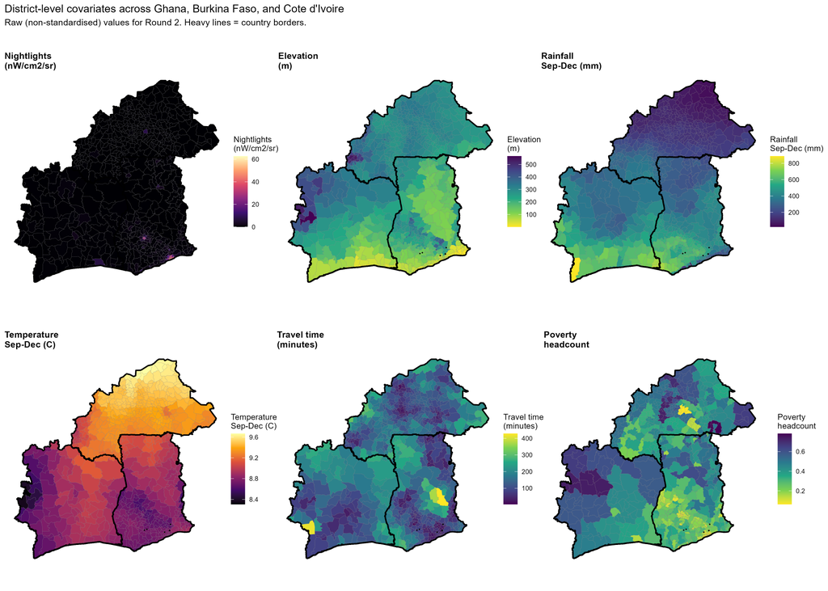

A material caveat applies to the poverty covariate. Ghana publishes district-level poverty figures, but Burkina Faso and Côte d’Ivoire only publish equivalent measures at the regional (admin-1) level. For these two countries, the regional poverty value is assigned uniformly to every district within the region, so within-region between-district variation in poverty is not captured. The poverty covariate should be interpreted as a region-level determinant for Burkina Faso and Côte d’Ivoire and as a district-level determinant for Ghana. The other six covariates are extracted at the district scale or finer for all three countries. The implication of this caveat is examined in Section $\ref{sec:limitations}$.

### Exploratory data analysis

Before model fitting, the seven covariates were inspected for univariate distribution, between-country shifts, and pairwise collinearity at the district level. Figure $\ref{fig:eda-univariate}$ shows kernel density estimates of each standardised covariate by country. The rainfall and temperature distributions show the expected Sahelian/Sudanian/Guinean gradient (Burkina Faso drier and hotter than Ghana and Côte d’Ivoire), elevation is bimodal in Ghana reflecting the Volta-region uplift, and nighttime lights are sharply right-skewed everywhere reflecting concentrated urbanisation.

[figure not shown]

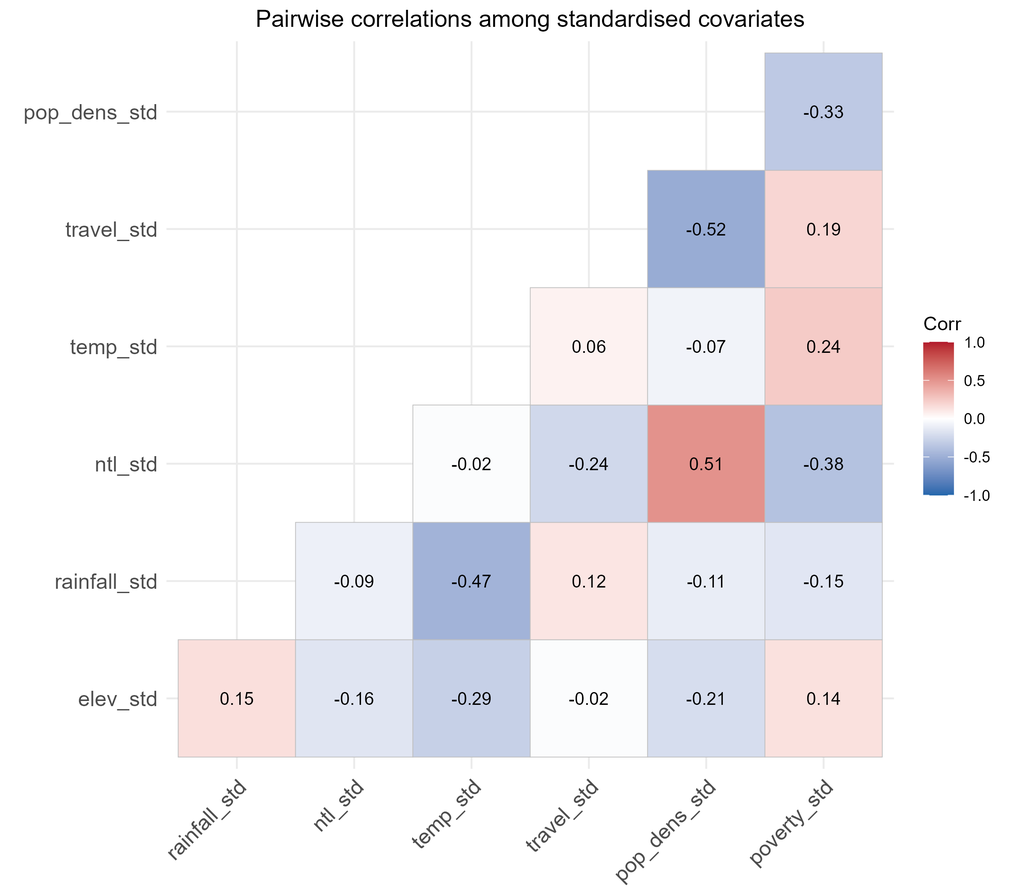

### Spatial adjacency

A combined country-time-district adjacency graph $W$ was constructed by identifying districts that share a common border. The graph has $N = 724$ nodes and $E = 2{,}056$ edges in total, of which 1,978 are within-country edges and 78 are cross-border edges. The BYM2 scaling factor [@riebler2016] was computed on this combined graph for the full cross-border specifications and on the disconnected within-country subgraph (with one component per country) for the within-country-only edge-deletion sensitivity model, following [@freni2018].

## Statistical framework

### From a simple linear model to the Fay-Herriot likelihood

Before stating the full hierarchical specification it is helpful to build it up from the simplest plausible starting point. Consider modelling the logit-transformed direct estimate $y_{it}$ from district $i$ in round $t$ as a function of district covariates $\mathbf{x}_{it}$. The simplest model is the linear specification
$$\begin{equation}
y_{it} = \mu + \mathbf{x}_{it}^{\top}\bm{\beta} + \varepsilon_{it},
\qquad \varepsilon_{it} \sim \mathcal{N}(0, \sigma^2),
\label{eq:simple-linear}
\end{equation}$$
with a global mean $\mu$, a single slope vector $\bm{\beta}$, and independent residuals of constant variance $\sigma^2$. This specification is unsatisfactory for two reasons. First, it implicitly treats the direct estimate as if it were measured without error, which is inconsistent with the survey-design machinery used to compute it; the resulting variance estimates would be wrong because $\sigma^2$ would have to absorb both true between-district variation and design-based sampling noise without being able to separate them. Second, it does not respect the spatial structure of the data: two neighbouring districts in similar climatic and ecological settings are no more similar in the model than two districts at opposite ends of the country.

The Fay-Herriot model [@fay1979] addresses the first problem by explicitly separating sampling error from latent variation. The direct estimate is treated as a noisy observation of a latent district-time prevalence $\theta_{it}$:
$$\begin{equation}
y_{it} \mid \theta_{it} \sim \mathcal{N}(\theta_{it}, \psi_{it}^2),
\label{eq:fh-lik}
\end{equation}$$
where $\psi_{it}^2$ is the district-time-specific sampling variance computed from the survey design and is treated as known. The latent quantity then has its own linking model,
$$\begin{equation}
\theta_{it} = \mu + \mathbf{x}_{it}^{\top}\bm{\beta} + e_{it},
\qquad e_{it} \sim \mathcal{N}(0, \sigma^2),
\label{eq:fh-link-simple}
\end{equation}$$
in which $e_{it}$ is the unobserved residual variation between districts at a fixed covariate value. This two-level specification separates the design-based noise $\psi_{it}^2$, which differs between districts and depends only on the sampling design, from the model-based residual $\sigma^2$, which is shared across districts and reflects the part of the prevalence-covariate relationship not explained by the covariates. The pre-specification of the sampling variance is the structural feature that gives the model its identifiability: with both $\psi_{it}^2$ and $\sigma^2$ free, the parameters would not be separately identified.

The standard treatment in the Fay-Herriot model is to treat $\psi_{it}^2$ as known and plug in the design-based estimate. The substantive justification is that the sampling variance is a property of the sampling design, not of the latent prevalence process being modelled: it is determined by the cluster count, the design weights, and the within-cluster homogeneity for the outcome, all of which are encoded in the survey-design metadata supplied with the recode files. In the Bayesian framing this corresponds to placing a point mass on the design-based estimate rather than a distribution. Treating $\psi_{it}^2$ as random would require a model for how the design-based estimator’s standard error varies across districts, and would also collide with the model-based $\sigma^2$: with both free, the two variance components are weakly identified [@you2002]. The standard modification, when $\psi_{it}^2$ is itself uncertain (typically because the cluster count per district is very small), is to smooth the design-based estimates through a generalised variance function before plugging them in [@rao2015]; this is a refinement on top of the treated-as-known assumption rather than a relaxation of it. The treated-as-known assumption is therefore a structural feature of the Fay-Herriot framework, not a simplifying choice, and we adopt it throughout.

The second limitation of the simple specification the absence of spatial structure is addressed in the next subsection by replacing the IID residual $e_{it}$ with a spatially structured component $b_i$. The full linking model used in the cross-border specifications is then
$$\begin{equation}
\theta_{it} = \mu + \alpha_{c[i]} + b_i + \eta_{c[i], t} + \gamma_{it}
+ \mathbf{x}_{it}^{\top}\bm{\beta}_{c[i]},
\label{eq:link}
\end{equation}$$
where $\mu$ is the global intercept, $\alpha_c$ is a country deviation identified by $\sum_c \alpha_c = 0$, $b_i$ is the district-level spatial random effect, $\eta_{c,t}$ is the temporal component (parameterised differently across models), $\gamma_{it}$ is an unstructured space-time interaction following the Type I classification of [@knorrheld2000], and $\bm{\beta}_c$ is a vector of country-specific covariate slopes partially pooled across countries through the hierarchical prior $\beta_{c,k} \sim \mathcal{N}(\bar\beta_k, \tau_k^2)$ [@gelman2006].

### BYM2 spatial prior

Spatial dependence between districts is modelled by the BYM2 prior [@riebler2016], a reparameterisation of the convolution model of [@besag1991]. The district-level spatial term is
$$\begin{equation}
b_i = \sigma_b\!\left(\sqrt{1-\phi}\,v_i + \sqrt{\phi/s}\,u_i\right),
\label{eq:bym2}
\end{equation}$$
with $v_i \sim \mathcal{N}(0, 1)$ the unstructured Gaussian component and $u \sim \mathrm{ICAR}(W)$ the structured intrinsic conditional autoregressive component on the adjacency matrix $W$. The ICAR density is
$$\begin{equation}
p(u \mid W) \propto
\exp\!\left(-\tfrac{1}{2}\sum_{(i,j) \in E}(u_i - u_j)^2\right),
\end{equation}$$
where $E$ is the set of edges of $W$. The sum-to-zero constraint $\sum_i u_i = 0$ identifies $u$. The scaling factor $s$ is computed from the generalised inverse of the structure matrix following [@riebler2016] so that $\sigma_b$ has consistent marginal-SD interpretation regardless of the adjacency structure. For graphs with multiple disconnected components the scaling factor is computed per component [@freni2018]. The mixing parameter $\phi \in (0, 1)$ governs the relative contribution of structured and unstructured spatial variation: $\phi = 0$ recovers a pure IID specification and $\phi = 1$ recovers a pure ICAR specification; treating $\phi$ as an unknown parameter lets the data determine the mixture [@morris2019].

### Computation and diagnostics

All models were fitted in Stan version 2.34 [@stan2024] via the `cmdstanr` interface, using the No-U-Turn Sampler [@hoffman2014]. Four chains were run in parallel with 1,500 warmup and 2,000 sampling iterations each. Cross-sectional and country-level models used `adapt_delta = 0.99` and `max_treedepth = 14`; cross-border models used `adapt_delta = 0.97` and `max_treedepth = 13`. Convergence was assessed by the rank-normalised $\hat{R}$ of [@vehtari2021], bulk and tail effective sample sizes, the number of divergent transitions reported by the sampler, and visual inspection of trace, rank and pairs plots. Non-centred parameterisations were used for all hierarchical components to mitigate funnel geometry [@betancourt2015]. Model comparison used approximate leave-one-out cross-validation [@vehtari2017] via the Pareto-smoothed importance sampling implementation in the `loo` package.

## Model sequence

This section sets out the full mathematical specification of each model fitted. The notation is shared throughout: $i$ indexes districts, $t \in \{1, 2\}$ indexes survey rounds, $c \in \{1, 2, 3\}$ indexes countries ($c = 1$ Ghana, $c = 2$ Côte d’Ivoire, $c = 3$ Burkina Faso), and $k$ indexes covariates.

### Model 1: Cross-sectional Ghana baseline (IID vs ICAR vs BYM2)

Model 1 fits the Fay-Herriot likelihood to Ghana 2022 alone, in three variants distinguished only by the form of the district-level spatial prior. The shared likelihood and linking model is
$$\begin{equation}
y_i \sim \mathcal{N}(\theta_i, \psi_i^2), \quad
\theta_i = \mu + b_i + \mathbf{x}_i^{\top}\bm{\beta},
\end{equation}$$
with $\mathbf{x}_i$ the standardised seven-covariate vector for district $i$. The three variants differ in how they treat the residual spatial variation $b_i$ equivalently, how they decompose the between-district variation not explained by the covariates.

The three variants are compared by LOO-CV [@vehtari2017] to motivate the spatial prior choice for the subsequent models. The BYM2 prior is the focus of the subsequent specifications because, unlike either of its limiting cases, it allows the data to determine the balance between structured and unstructured residual variation rather than imposing one or the other by assumption.

### Model 2: Country-level space-time models

Model 2 fits a country-specific Fay-Herriot space-time model independently to each country. For country $c$,
$$\begin{equation}
\theta_{it} = \mu_c + b_i + \delta_{c,t} + \gamma_{it} +
\mathbf{x}_{it}^{\top}\bm{\beta}_c,
\end{equation}$$
where $\delta_{c, 1} = 0$ identifies $\mu_c$ as the Round 1 mean and $\delta_{c, 2}$ is the round-to-round shift on the logit scale, $\gamma_{it} \sim \mathcal{N}(0, \sigma_\gamma^2)$ is an unstructured space-time interaction following the Type I classification of [@knorrheld2000], and $b_i$ is BYM2 with country-specific scaling factor on the within-country adjacency graph.

### Model 3: Three-country single-time

Model 3 is the first multi-country specification. It joins all three countries on the combined 724-district adjacency graph $W$ but uses only the temporally aligned second survey round (Burkina Faso 2021, Côte d’Ivoire 2021, Ghana 2022). With every district surveyed within a one-year window, cross-border smoothing operates on contemporaneous surfaces by construction:
$$\begin{equation}
\theta_i = \mu + \alpha_{c[i]} + b_i +
\mathbf{x}_i^{\top}\bm{\beta}_{c[i]},
\end{equation}$$
with $b_i$ BYM2 on $W$, $\sum_c \alpha_c = 0$, and $\beta_{c,k} \sim \mathcal{N}(\bar\beta_k, \tau_k^2)$.

The BYM2 prior is justified for Model 3 by the substantive ecology of *Plasmodium falciparum* malaria in West Africa. *Plasmodium falciparum* is the dominant parasite species across the three countries and is transmitted by the same two principal *Anopheles* vector complexes (*An. gambiae sensu lato* and *An. funestus*) [@who2023]. Transmission is strongly seasonal across the study region: the West African monsoon drives a wet-season transmission peak that propagates from south to north between June and October, and the climatic determinants of vector survival (rainfall, temperature, humidity) are spatially smooth at scales much larger than a single district [@bhatt2015]. The vectors disperse over kilometres-scale ranges from breeding sites and human movement disperses parasites over much longer distances, so the relevant biological process is not bounded by the national borders that cut across the regional climatic gradient. Two districts on opposite sides of a national border that share rainfall, temperature and ecology should therefore have similar prevalence after adjustment for covariates, and the BYM2 prior on the combined adjacency graph expresses this prior expectation. The mixing parameter $\phi$ allows the data to determine whether the residual variation is predominantly structured (as expected if the model has not captured all of the ecological smoothness) or unstructured (as expected if the covariates fully capture the regional structure).

The covariate set for Model 3 (and for Model 4 below) is selected to capture the structural and ecological determinants of malaria transmission. Rainfall and temperature are taken at the actual DHS fieldwork months of each survey, so the covariate panel implicitly encodes the seasonality of vector activity through the level of these two variables rather than through an explicit seasonality dummy; elevation captures the temperature gradient at altitude; nighttime lights and population density capture urbanisation and human density; travel time captures programme accessibility; and the multidimensional poverty index captures household-level deprivation. The substantive basis for each is set out in Table $\ref{tab:covariates}$. The expectation under this covariate set is that residual spatial variation after adjustment is smooth, supporting the BYM2 form of the spatial prior.

### Model 4: Three-country two-time, calendar-year fixed effect

Model 4 extends Model 3 to both rounds. The temporal effect enters as a fixed effect for the actual calendar year of each survey, centred at 2016, with a country-specific linear slope:
$$\begin{equation}
\theta_{it} = \mu + \alpha_{c[i]} + b_i + \delta_{c[i]} \cdot
\widetilde{\text{yr}}_{it}
+ \gamma_{it} +
\mathbf{x}_{it}^{\top}\bm{\beta}_{c[i]},
\label{eq:m4}
\end{equation}$$
with $\widetilde{\text{yr}}_{it} = \text{yr}_{it} - 2016$ and $\delta_c \sim \mathcal{N}(\bar\delta, \sigma_\delta^2)$. Following [@wakefield2020], the temporal effect is expressed on calendar-year scale rather than as a round-to-round wave indicator: the surveys are not synchronised across countries (Round 1 spans 2010 to 2014, Round 2 spans 2021 to 2022) and a wave-indicator parameterisation would conflate the country-specific elapsed time between rounds with the country-specific rate of change. The country-specific slope $\delta_c$ is the annual rate of change in the logit prevalence and is directly comparable across countries; the between-round odds ratio for country $c$ is $\exp(\delta_c \cdot \Delta\text{yr}_c)$ where $\Delta\text{yr}_c$ is the actual elapsed years between rounds.

The BYM2 spatial field $b_i$ is time-invariant in Model 4: a single spatial surface is assumed to describe the residual spatial structure across both rounds. The substantive justification is that the structural drivers of the residual spatial gradient (long-run climate norms, elevation, the durable component of urbanisation, accessibility) are slow-moving relative to the 8-to-11-year study window [@bhatt2015; @weiss2020]. Whether this assumption is plausible for the residual variation after adjusting for the time-varying covariates (rainfall and temperature at the survey months, nighttime lights at the survey year) is an empirical question; the edge-deletion sensitivity, Model 4a, and Model 4b each probe a different aspect of this assumption.

A natural further question is whether the spatial field itself should be allowed to differ between rounds, in the sense of fitting $b_{i, t}$ rather than $b_i$. With only two time points per district this is a strongly identifiability-limited specification: with no within-area replication, the two per-round fields cannot be separated from a saturated round-by-district interaction. We do not fit a separate BYM2 per year for this reason. The substantive considerations also point against it. The dominant structural drivers of malaria risk in West Africa long-run climate, elevation, vector ecology  
change on decadal-or-longer timescales [@bhatt2015; @weiss2020], so the residual spatial gradient after adjustment for the time-varying covariates is expected to be approximately time-invariant. With more than two survey rounds per country the time-variation could be explored through a Knorr-Held Type II or Type IV space-time interaction [@knorrheld2000; @goicoa2018]; in the present two-round setting Model 4a (covariate slopes varying by round) and Model 4b (country-specific BYM2) are the available probes of the time-invariance assumption.

### Model 4a: Country-year interaction

Model 4a relaxes the time-invariance of the covariate slopes in Model 4 by allowing the covariate-prevalence relationship to differ between rounds within each country:
$$\begin{equation}
\theta_{it} = \mu + \alpha_{c[i]} + b_i + \delta_{c[i]} \cdot
\widetilde{\text{yr}}_{it}
+ \gamma_{it} + \mathbf{x}_{it}^{\top}\bm{\beta}_{c[i],
t[i]},
\end{equation}$$
with $\beta_{c, t, k} \sim \mathcal{N}(\bar\beta_k, \tau_k^2)$, giving 42 slope parameters partially pooled around seven regional means. This is the country-year interaction specification: within each country, the covariate slopes are free to differ by round; across countries the slopes are partially pooled toward a shared regional mean. Two time points per district are insufficient to support a district-year random slope, so the country-year interaction is the finest interaction specification supportable here. The substantive question is whether the covariate-prevalence relationships are stable across the study window at the country scale, or whether they have shifted between rounds.

### Model 4b: Country-specific BYM2 components

Model 4b replaces the shared BYM2 hyperparameters of Model 4 with country-specific ones, following the disconnected-graph framework of [@freni2018] and the country-specific BYM2 implementation of [@donegan2021]. The cross-border edges are removed from the adjacency graph, and each country gets its own variance $\sigma_{b,c}$ and mixing parameter $\phi_c$:
$$\begin{equation}
b_i = \sigma_{b, c[i]}\!\left(\sqrt{1 - \phi_{c[i]}}\,v_i
+ \sqrt{\phi_{c[i]} / s_{c[i]}}\,u_i\right),
\end{equation}$$
with $u$ ICAR on the within-country adjacency $W'$, per-country sum-to-zero $\sum_{i \in c} u_i = 0$, and per-country scaling factor $s_c$. The substantive question is whether the three countries have materially different residual spatial structures.

### Edge-deletion sensitivity

The edge-deletion sensitivity isolates the contribution of the 78 cross-border edges by removing them and refitting Model 4 with the remaining specification (covariate slopes, country intercepts, temporal slopes, BYM2 hyperparameters) unchanged. The scaling factor is computed per component [@freni2018] and applied per district. The rationale follows the disconnected-graph diagnostic of [@earnest2007] and the spatial-sensitivity reasoning of [@best2005]: when a spatial smoother joins areas across an administrative or hypothetical boundary, comparing the fit with and without the joining edges quantifies the substantive contribution of cross-boundary smoothing relative to the within-boundary structure. Here the comparison addresses two questions: whether the cross-border edges contribute to predictive performance, and whether the substantive parameter estimates (country-year slopes, regional covariate effects) depend on the inclusion of cross-border smoothing.

## Model comparison

Models within comparable observation blocks are compared by approximate leave-one-out cross-validation [@vehtari2017]. The expected log predictive density (ELPD) is the criterion; larger ELPD indicates better expected predictive performance. Differences in ELPD between models are compared against the standard error of the difference; a difference smaller than two standard errors is considered not statistically distinguishable from zero [@vehtari2017]. Comparisons are only made between models fitted to the same set of observations.

# Results

## Cross-sectional baseline: IID, ICAR and BYM2

The three Ghana 2022 cross-sectional variants converged with all parameters showing $\hat{R} < 1.02$ and bulk effective sample sizes above 300. Each prior treats the residual between-district variation differently. The IID variant attributes all residual variation to unstructured district-level noise, with the implication that neighbouring districts are not preferentially correlated. The pure ICAR variant attributes all residual variation to a spatially structured Markov random field, with the implication that residuals are forced toward those of their neighbours through the precision-matrix structure of the adjacency graph. The BYM2 variant allows the data to mix the two: the marginal SD $\sigma_b$ is shared, and the mixing parameter $\phi$ governs the share of structured variation.

The LOO-CV comparison is summarised in Table $\ref{tab:m1-loo}$ and Figure $\ref{fig:loo-cv-comparison}$.

Model 1 cross-sectional baseline (Ghana 2022): leave-one-out cross-validation comparison of IID, pure ICAR and BYM2 spatial priors. ELPD differences relative to the best variant; standard errors of the difference computed pairwise. The BYM2 variant achieves the best ELPD; the pure ICAR variant is the only one whose ELPD difference exceeds two standard errors, ruling it out at the conventional threshold.

| Variant | ELPD | SE(ELPD) | ELPD diff | SE diff |
| --- | --- | --- | --- | --- |
| BYM2 | -104.3 | 7.9 | 0.0 | 0.0 |
| IID | -107.0 | 8.1 | -2.7 | 1.8 |
| Pure ICAR | -113.2 | 8.4 | -8.9 | 4.2 |

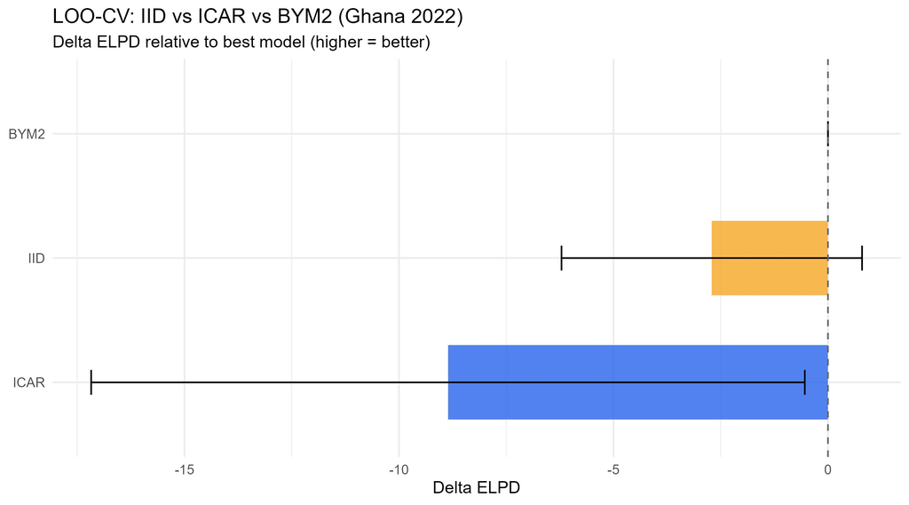

Leave-one-out cross-validation comparison of three spatial priors on the Ghana 2022 cross-section. Bars show the ELPD difference relative to the best model with two-standard-error intervals. The BYM2 prior is preferred over the IID alternative and substantially over the pure ICAR alternative.

The BYM2 specification achieves the best ELPD with an estimate of $-104.3$ (SE 7.9). The IID specification is 2.7 ELPD units behind (SE 1.8), and the pure ICAR specification is 8.9 ELPD units behind (SE 4.2). The ICAR penalty exceeds two standard errors, so the data provide clear evidence against the pure ICAR prior at this scale; the IID alternative is within 1.5 standard errors of BYM2, but the BYM2 parameter estimates indicate that the data prefer a substantial structured component. The BYM2 prior is adopted as the spatial prior for all subsequent models.

The Model 1 BYM2 posterior estimates of the structural parameters are $\mu = -1.82$ (90 per cent CrI $[-2.02, -1.62]$), $\sigma_b = 0.88$ $[0.68, 1.15]$, and $\phi = 0.44$ $[0.17, 0.72]$. The marginal national prevalence is $p^{\text{nat}} = 14.1$ per cent $[11.8, 16.5]$, consistent with the direct national estimate for Ghana 2022. The maps of direct, IID, ICAR and BYM2 estimates for Ghana 2022 are shown in Figure $\ref{fig:m1-maps}$. The BYM2 surface reproduces the broad north-to-south gradient visible in the direct estimates while filling in the unsampled districts with spatially coherent predictions.

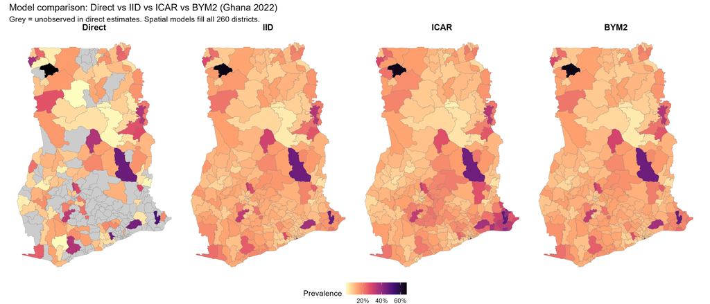

## Country-level space-time models

The country-level Model 2 fits converged for all three countries with $\hat{R} < 1.01$ for all top-level parameters and bulk effective sample sizes between 600 and 5,500. The key parameter estimates are summarised in Table $\ref{tab:m2-params}$ and the implied national prevalence trajectories are shown in Table $\ref{tab:m2-prev}$.

Model 2 (country-level space-time) posterior estimates of structural parameters. Posterior median with 90 per cent CrI.

| Country | $\mu$ | $\sigma_b$ | $\phi$ | $\sigma_\gamma$ | $\delta_2$ |
| --- | --- | --- | --- | --- | --- |
| GHA | -0.83 [-0.94, -0.71] | 0.72 [0.56, 0.94] | 0.47 [0.20, 0.73] | 0.52 [0.45, 0.59] | -1.14 [-1.30, -0.98] |
| BFA | 0.91 [0.74, 1.07] | 1.04 [0.78, 1.36] | 0.64 [0.37, 0.84] | 0.51 [0.45, 0.58] | -2.52 [-2.82, -2.19] |
| CIV | -1.56 [-1.75, -1.38] | 0.82 [0.55, 1.23] | 0.59 [0.25, 0.87] | 0.48 [0.40, 0.56] | 0.78 [0.50, 1.06] |

Implied national paediatric prevalence by round, country-level Model 2. Posterior medians with 90 per cent CrI.

| Country | Round 1 | Round 2 | Odds ratio R2/R1 |
| --- | --- | --- | --- |
| GHA | 30.5% [28.1, 33.1] | 12.3% [10.9, 13.8] | 0.32 |
| BFA | 71.2% [67.7, 74.5] | 16.8% [14.3, 19.5] | 0.08 |
| CIV | 17.4% [14.8, 20.1] | 31.3% [27.9, 34.8] | 2.13 |

The country-level models show three different trajectories. Ghana declined from 30.5 per cent in 2014 to 12.3 per cent in 2022, an odds ratio of 0.32. Burkina Faso showed the largest decline in absolute terms, from 71.2 per cent in 2010 to 16.8 per cent in 2021, with the largest country-level $\sigma_b$ reflecting substantial residual heterogeneity across districts. Côte d’Ivoire showed an increase from 17.4 to 31.3 per cent between 2012 and 2021. Figure $\ref{fig:m2-covariates}$ shows the posterior covariate effect estimates from the three country-level models.

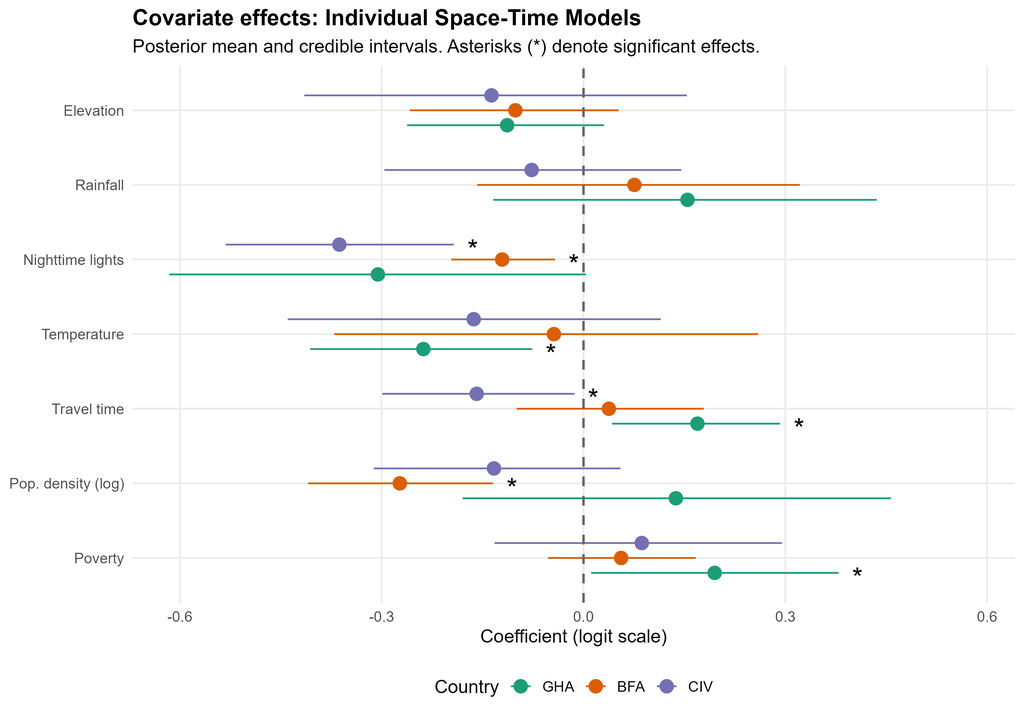

Covariate effects from the three country-level (Model 2) specifications. Points are posterior means with 90 per cent credible intervals; asterisks denote covariates whose credible interval excludes zero.

## Three-country cross-border models

The four cross-border specifications were fitted to the full district-round panel. Their key structural parameters are summarised in Table $\ref{tab:m4-family}$.

Cross-border model family: key structural parameter estimates. Posterior medians with 90 per cent CrI. Model 4b has per-country spatial parameters: $\sigma_b = (0.15, 0.14, 0.66)$ and $\phi = (0.62, 0.63, 0.72)$ for GHA, CIV, BFA respectively.

| Parameter | Model 4 | Model 4a | Edge-del | Model 4b |
| --- | --- | --- | --- | --- |
| $\mu$ | -1.14 [-1.33, -0.95] | -1.15 [-1.34, -0.95] | -0.68 [-1.32, 0.27] | -1.02 [-1.27, -0.42] |
| $\sigma_b$ | 0.66 [0.40, 0.91] | 0.70 [0.45, 0.91] | 0.49 [0.25, 0.72] | see note |
| $\phi$ | 0.85 [0.57, 0.96] | 0.86 [0.63, 0.97] | 0.79 [0.46, 0.95] | see note |
| $\sigma_\gamma$ | 0.71 [0.66, 0.76] | 0.70 [0.64, 0.75] | 0.73 [0.67, 0.78] | 0.72 [0.67, 0.77] |
| $\delta_{\text{GHA}}$ | -0.143 [-0.166, -0.120] | -0.137 [-0.163, -0.118] | -0.142 [-0.165, -0.118] | -0.142 [-0.166, -0.120] |
| $\delta_{\text{CIV}}$ | 0.080 [0.049, 0.110] | 0.076 [0.047, 0.106] | 0.079 [0.049, 0.110] | 0.080 [0.050, 0.108] |
| $\delta_{\text{BFA}}$ | -0.230 [-0.255, -0.206] | -0.232 [-0.254, -0.205] | -0.233 [-0.256, -0.210] | -0.229 [-0.254, -0.205] |
| $\bar\beta_{\text{NTL}}$ | -0.19 [-0.43, 0.04] | -0.17 [-0.27, 0.10] | -0.19 [-0.43, 0.10] | -0.21 [-0.46, 0.07] |

### Results from Model 4

The Model 4 estimates are consistent with Model 2 in sign and approximate magnitude. The global intercept is $\mu = -1.14$ on the logit scale. The spatial standard deviation $\sigma_b = 0.66$ is well identified, and the mixing parameter $\phi = 0.85$ indicates that the residual spatial variation is predominantly structured. The country-year slopes recover the three trajectories at calendar-year scale: Ghana $\delta = -0.143$ $[-0.166, -0.120]$ per year; Côte d’Ivoire $\delta = +0.080$ $[0.049, 0.110]$ per year; Burkina Faso $\delta = -0.230$ $[-0.255, -0.206]$ per year. The implied between-round odds ratios are 0.32 for Ghana (8-year window), 2.09 for Côte d’Ivoire (9-year window) and 0.08 for Burkina Faso (11-year window), all consistent with Model 2. The strongest regional protective effect is for nighttime lights with $\bar\beta = -0.19$, followed by population density at $-0.18$ and temperature at $-0.14$. Elevation, rainfall and travel time have regional credible intervals that span zero, and poverty has a regional median of $+0.09$.

### Results from Model 4a

[figure not shown]

### Edge-deletion sensitivity

Removing the 78 cross-border edges and re-fitting Model 4 yields the edge-deletion specification. The country-year slopes are essentially unchanged ($\delta_{\text{GHA}} = -0.142$, $\delta_{\text{CIV}} = 0.079$, $\delta_{\text{BFA}} = -0.233$), as are the regional covariate effects. The spatial standard deviation drops from $\sigma_b = 0.66$ to $\sigma_b = 0.49$, reflecting that some of the spatial variation previously absorbed by the cross-border smoothing is redistributed into the unstructured Gaussian term and the country intercepts, with the global intercept becoming weakly identified at $\mu = -0.68$. The mixing parameter $\phi = 0.79$ remains high.

## Sensitivity comparison: LOO across the cross-border models

Table $\ref{tab:sens-loo}$ presents the leave-one-out cross-validation comparison across the four cross-border two-time specifications, all fitted on the same observation set so the comparison is valid in the sense of [@vehtari2017].

Leave-one-out cross-validation across the cross-border two-time models. ELPD difference is computed against the best model; differences smaller than two standard errors are not statistically distinguishable from zero .

| Model | ELPD diff | SE diff | ELPD | SE(ELPD) |
| --- | --- | --- | --- | --- |
| Model 4a (time-varying betas) | 0.0 | 0.0 | -465.2 | 21.2 |
| Edge-deletion (within-country only) | -2.3 | 4.9 | -467.5 | 21.3 |
| Model 4 (shared BYM2, full graph) | -3.4 | 4.9 | -468.6 | 21.1 |
| Model 4b (country-specific BYM2) | -5.9 | 5.3 | -471.2 | 21.5 |

Model 4a achieves the best ELPD by a small margin. Model 4 is 3.4 ELPD units behind Model 4a with a standard error of 4.9 units (0.7 standard errors). The edge-deletion specification is 2.3 ELPD units behind (0.5 standard errors), and Model 4b is 5.9 ELPD units behind with a standard error of 5.3 (1.1 standard errors). All four specifications are within 6 ELPD units of each other against standard errors of around 5, and none of the three structural relaxations of Model 4 produces a detectable improvement in expected predictive performance.

# Discussion

## Summary of results

The Bayesian space-time Fay-Herriot framework with BYM2 spatial prior produced district-level estimates of under-five malaria prevalence for Burkina Faso, Côte d’Ivoire and Ghana over two DHS rounds spanning the 2010 to 2022 period. The cross-sectional baseline confirmed that the BYM2 prior is preferred over the IID and ICAR alternatives by LOO-CV, supporting its use across the subsequent models. The country-level and three-country specifications agree on three distinct trajectories. Ghana and Burkina Faso showed substantial declines, with Burkina Faso’s decline the largest in absolute terms (from 71 to 17 per cent), while Côte d’Ivoire showed an increase from 17 to 31 per cent between 2012 and 2021. The preferred cross-border specification (Model 4) recovers these trajectories on a calendar-year scale with country-specific annual rates of change.

The mixing parameter $\phi$ from Model 4 is 0.85 with credible interval well above 0.5, indicating that the residual spatial variation after conditioning on the seven structural covariates is predominantly structured. This is consistent with the substantive expectation that the structural covariates capture the broad regional gradient and the spatial residual reflects unmeasured but spatially smooth factors such as intervention history, housing quality and vector species composition.

## Sensitivity analysis and the cross-border assumption

Three structural relaxations of Model 4 were fitted as sensitivity specifications. Model 4a allows covariate slopes to differ between rounds, testing the time-invariance assumption. The Model 4 edge-deletion removes the 78 cross-border edges, testing whether cross-border smoothing is doing useful work. Model 4b replaces the shared BYM2 hyperparameters with country-specific ones, testing the assumption that the three countries share spatial structure.

The LOO-CV comparison in Table $\ref{tab:sens-loo}$ shows that none of the three relaxations produces a detectable improvement over Model 4. The posterior parameter comparisons in Table $\ref{tab:m4-family}$ reinforce this: the country-year slopes are essentially identical across all four specifications; the regional covariate effects are similar within Monte Carlo error; and the Round 1 versus Round 2 covariate slopes in Model 4a do not differ materially for the great majority of country-covariate pairs. Substantively, Model 4 is parsimoniously adequate against all three structural alternatives, and the simpler specification is retained.

The edge-deletion result deserves attention. Removing the cross-border edges substantially weakens identification of the global intercept $\mu$ and produces a corresponding widening of the country intercepts $\alpha_c$, but the substantive parameters of interest (country-year slopes, regional covariate effects, between-country slope variation) are essentially unchanged. The cross-border edges in Model 4 are doing identification work for the global intercept and the country intercepts, but the data-driven findings about trajectories, covariate effects and between-country heterogeneity do not depend on them. This is a useful negative result: it tells us that the substantive findings are robust to whether the spatial smoother shares information across national borders.

## Relation to the literature

The country-specific trajectories are broadly consistent with the published literature. The Burkina Faso decline matches the trajectory documented in [@bhatt2015] and updated in [@weiss2020] for the Sahelian zone, where the rollout of seasonal malaria chemoprevention from 2014 onwards has been associated with substantial reductions in paediatric prevalence. The Ghana decline matches the trajectory in the country’s own national malaria control programme reports through the WHO World Malaria Report series [@who2023]. The Côte d’Ivoire increase between 2012 and 2021 is less commonly emphasised in summary regional reports but is consistent with the country’s own DHS reports and with the broader observation in [@weiss2020] that progress against malaria has not been uniform across West Africa.

The methodological framework is in the tradition of [@mercer2015; @wakefield2020] for area-level SAE of paediatric prevalence outcomes, with the BYM2 prior of [@riebler2016] and the disconnected-graph treatment of [@freni2018]. The multi-country cross-border specification on a single combined adjacency graph is, to the best of our knowledge, one of the first applications of this design for paediatric malaria prevalence in West Africa.

## Implications for practice

The district-level estimates produced by the model are suited to target resource allocation for malaria intervention programmes within each country and across the region. The substantially smaller uncertainty of the model-based estimates compared with the direct estimates, particularly for the many districts not directly sampled in a given round, makes them useful as inputs to programme planning. The between-round trajectory information from Model 4 quantifies the rate of progress at the country level on a comparable calendar scale across the three countries, allowing direct comparison of progress that the round-indicator parameterisation would obscure.

## Limitations

Several limitations should be borne in mind.

First, the poverty covariate is available at the district scale only for Ghana. For Burkina Faso and Côte d’Ivoire, regional (admin-1) poverty values were assigned uniformly to every district within the region, so within-region variation in this covariate is not captured. This is a known limitation of nationally available poverty data and reflects the resolution at which the underlying surveys are designed to be representative. The implication is that the poverty covariate coefficient should be interpreted as a region-level determinant for Burkina Faso and Côte d’Ivoire, and that any residual within-region variation correlated with poverty is absorbed into the spatial random effect.

Second, the BYM2 spatial field is assumed to be time-invariant in Models 3, 4, 4a and 4b. The substantive justification is that the structural drivers of the regional malaria gradient (climate, elevation, urbanisation, accessibility) move on decadal timescales [@bhatt2015; @weiss2020], so the spatial residual after conditioning on the covariates should also be time-stable at the district scale across the study window. Fitting a separate BYM2 field per round with only two time points would be weakly identified and was not attempted. With more survey rounds this assumption could be relaxed through the Knorr-Held Type II or Type IV interactions [@knorrheld2000; @goicoa2018].

Third, the sampling variance $\psi_{it}^2$ is treated as known following the standard Fay-Herriot approach [@you2002]. For districts with very few clusters the design-based variance estimate is itself uncertain; the Fay-Herriot framework does not propagate this uncertainty. Smoothing the variance estimate through a generalised variance function is a natural extension.

Fourth, the cross-border edges in the shared adjacency graph assume shared transmission ecology across borders. While there is a strong substantive case for this from vector ecology and human movement [@bhatt2015; @weiss2020; @who2023], the data in this particular application do not strongly select the cross-border specification over the within-country-only alternative. This does not undermine the broader methodological case for the shared adjacency graph but suggests that applications with longer time series or more countries would be informative.

Fifth, external validation against the Malaria Atlas Project [@bhatt2015; @weiss2020] surfaces was set out in the methodological workbook but the comparison itself was not completed within this report. The MAP comparison would provide concordance evidence with an independently developed geostatistical modelling tradition and is the natural next step.

# Conclusions

This work has presented a Bayesian area-level small area estimation framework for under-five malaria prevalence across Burkina Faso, Côte d’Ivoire and Ghana over the 2010 to 2022 period. The BYM2 spatial prior was selected empirically over the IID and ICAR alternatives in a cross-sectional baseline and adopted for the country-level and cross-border models. The country-level results showed three different trajectories: substantial declines in Burkina Faso and Ghana, and an increase in Côte d’Ivoire, with these findings carrying over to the cross-border specifications. The preferred cross-border model (Model 4) parameterises country-specific trajectories as annual rates of change on calendar year, supporting direct between-country comparison.

A formal sensitivity analysis tested three structural relaxations: time-varying covariate slopes (Model 4a), removal of cross-border edges (edge-deletion), and country-specific BYM2 hyperparameters (Model 4b). None produced a detectable improvement in LOO-CV, and the substantive parameters of interest were essentially unchanged across all four specifications. Model 4 is parsimoniously adequate against these alternatives and is retained as the preferred specification.

The findings are consistent with the published regional literature on malaria trajectories in West Africa, and the methodological framework provides a transparent basis for producing district-level paediatric prevalence estimates with quantified uncertainty for the three study countries. The framework is directly applicable to other Sahelian and Guinean countries where the DHS RDT modules have been conducted, and extends to other outcomes available in the DHS recode files.